# Homework 2

Julian Ghadially

August 17, 2015

## Problem 1: Flights at Austin Bergstrom International Airport

Analysis shows that departure delay time at Austin Bergstrom Airport increases as it gets later in the day, see figure one. Furthermore, United Airlines is drastically less punctual than the other major airlines. This is not due to a smaller number of flights since our data contains 1866 United Airlines flights.

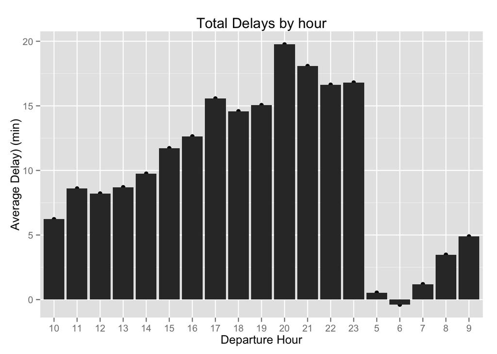

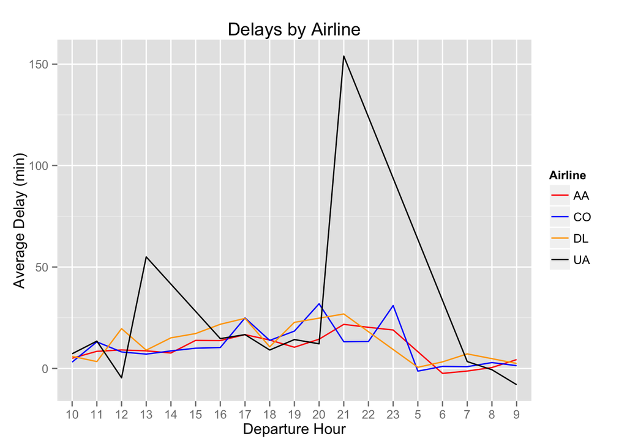

## Problem 2: Reuters Author Attribution

**Bag of Words Model**

In this exercise, works from 50 authors are analysed in order to attribute authorship to unknown text files from the same set of authors. Text is represented using a bag of words model. In the bag of words model, each document is a bag with counts associated with each word from the corpora of all authors. In order to best represent the text using bag of words, common words are ommitted, since they don’t add as much value as the uncommon words. Sparse words are also ommitted.

**Calculating Multinomial Probability Vector**

The multinomial probability vector is made up of the likelihood of each word for each author involved. In order to do this, the document term matrix is condensed into counts of words per author. These counts are converted into likelihoods by dividing by the total corpora word count. A laplacian smoothing term of 1/2500 is added to each count in order to estimate the likelihood of words unseen by the training corpora.

**Handling words in the test set that are not present in the training data**

The naive-bayes model is trained solely on documents from the training text, however, words from the test set are included in the document term matrices for the training set. the likelihoods of the unseen test words in the training set are equal to the value dictated by Laplacian smoothing. Because this is likelihood we would assign them if they were in seperate document term matrices, it is acceptable to include them in the set of training words. Another way to handle the unseen test words would be to use only the intersection of words between the two corpora. However, this biases the training set to include information from the test set through omission of words unique to the training set.

**Naive-Bayes Performance**

The Naive-Bayes model described above attributed the correct author **57%** of the time. This is very good compared to a 2% chance of getting the correct author with no model at all. Also, author attribution varied for different authors. the table below displays accuracy for each author. Six authors were very troublesome to predict, with classification scores of 20% or less.

```
## [1] 0.5728
```

```
##                    x    y
## 1      AaronPressman 0.70
## 2         AlanCrosby 0.44
## 3     AlexanderSmith 0.96
## 4    BenjaminKangLim 0.16
## 5      BernardHickey 0.50
## 6        BradDorfman 0.86
## 7   DarrenSchuettler 0.36
## 8        DavidLawder 0.14
## 9      EdnaFernandes 0.08
## 10       EricAuchard 0.58
## 11    FumikoFujisaki 0.98
## 12    GrahamEarnshaw 0.74
## 13  HeatherScoffield 0.32
## 14     JaneMacartney 0.64
```

[output cut: 36 more lines]

**Random Forest Model**

```
##                    x    y
## 1      AaronPressman 0.86
## 2         AlanCrosby 0.86
## 3     AlexanderSmith 0.56
## 4    BenjaminKangLim 0.46
## 5      BernardHickey 0.60
## 6        BradDorfman 0.48
## 7   DarrenSchuettler 0.84
## 8        DavidLawder 0.88
## 9      EdnaFernandes 0.52
## 10       EricAuchard 0.54
## 11    FumikoFujisaki 0.92
## 12    GrahamEarnshaw 0.76
## 13  HeatherScoffield 0.88
## 14     JaneMacartney 0.46
```

[output cut: 36 more lines]

## Problem 3: Association Rule Mining

The drawback of the association rules found is that there might be a statistical dependence resulting from milk and vegetables being very common. Thus, we’d like to also find association rules for less common items. We can select for higher lifts, in order to consider items with less support. (Lift evaluates confidence divided by support).

When we select for higher lifts, we find many interesting association rules, which have high confidences. These are shown below under, “Using Lift.” In particular we find that 90% of itemsets containing liquor and wine also contain bottled beer. Hamburger meat, whiped/sour cream, and yogurt is associated with butter. Also, popcorn and soda item sets are associated with salty snacks.

These item sets make sense and are not as reliant on high statistical dependence found with popular items like milk and vegetables.

```
##    lhs                     rhs                   support confidence     lift
## 1  {curd,
##     yogurt}             => {whole milk}       0.01006609  0.5823529 2.279125
## 2  {butter,
##     other vegetables}   => {whole milk}       0.01148958  0.5736041 2.244885
## 3  {domestic eggs,
##     other vegetables}   => {whole milk}       0.01230300  0.5525114 2.162336
## 4  {whipped/sour cream,
##     yogurt}             => {whole milk}       0.01087951  0.5245098 2.052747
## 5  {other vegetables,
##     whipped/sour cream} => {whole milk}       0.01464159  0.5070423 1.984385
## 6  {other vegetables,
##     pip fruit}          => {whole milk}       0.01352313  0.5175097 2.025351
## 7  {citrus fruit,
##     root vegetables}    => {other vegetables} 0.01037112  0.5862069 3.029608
## 8  {root vegetables,
##     tropical fruit}     => {other vegetables} 0.01230300  0.5845411 3.020999
## 9  {root vegetables,
##     tropical fruit}     => {whole milk}       0.01199797  0.5700483 2.230969
## 10 {tropical fruit,
##     yogurt}             => {whole milk}       0.01514997  0.5173611 2.024770
## 11 {root vegetables,
##     yogurt}             => {other vegetables} 0.01291307  0.5000000 2.584078
## 12 {root vegetables,
##     yogurt}             => {whole milk}       0.01453991  0.5629921 2.203354
## 13 {rolls/buns,
##     root vegetables}    => {other vegetables} 0.01220132  0.5020921 2.594890
## 14 {rolls/buns,
##     root vegetables}    => {whole milk}       0.01270971  0.5230126 2.046888
## 15 {other vegetables,
##     yogurt}             => {whole milk}       0.02226741  0.5128806 2.007235
```

### Using Lift

```
##   lhs                        rhs                  support confidence     lift
## 1 {liquor,
##    red/blush wine}        => {bottled beer}   0.001931876  0.9047619 11.23527
## 2 {popcorn,
##    soda}                  => {salty snack}    0.001220132  0.6315789 16.69779
## 3 {Instant food products,
##    soda}                  => {hamburger meat} 0.001220132  0.6315789 18.99565
## 4 {Instant food products,
##    whole milk}            => {hamburger meat} 0.001525165  0.5000000 15.03823
## 5 {ham,
##    processed cheese}      => {white bread}    0.001931876  0.6333333 15.04549
## 6 {domestic eggs,
##    processed cheese}      => {white bread}    0.001118454  0.5238095 12.44364
## 7 {baking powder,
##    flour}                 => {sugar}          0.001016777  0.5555556 16.40807
## 8 {hard cheese,
##    whipped/sour cream,
##    yogurt}                => {butter}         0.001016777  0.5882353 10.61522
## 9 {hamburger meat,
##    whipped/sour cream,
##    yogurt}                => {butter}         0.001016777  0.6250000 11.27867
```